# Esporte e dinheiro: uma análise da lista da Forbes

Sports and Money: A Forbes List Analysis

Por *Alexandre Santos

# **Esporte é negócio**

### *Sport is business*

Nas últimas décadas com o aumento do marketing esportivo, aumento do acesso à informação e a divulgação de atletas e marcas por diversos meios de comunicação observamos um aumento significativo de rendimento financeiro de atletas, equipes esportivas e principalmente do consumo do esporte como entretenimento.

[figure not shown]

Foto da Matthew Henry do [Burst](https://www.shopify.com.br/burst?utm_campaign=photo_credit&utm_content=Fotos+em+HD+de+Torcedor+no+jogo+de+basquete&utm_medium=referral&utm_source=credit)

No entanto, com a expressiva movimentação financeira, surge algumas dúvidas e principalmente curiosidades a respeito de quais modalidades, países e atletas mais lucraram com esse aumento do consumo do esporte. Portanto, vamos imergir neste mundo dos superastros e esportes das últimas décadas, avaliando o avanço do esporte como negócio. Por fim, analisaremos como os atletas brasileiros evoluíram nestas 3 décadas com relação aos seus lucros e quem foram esses atletas citados pela Forbes.

#### *Os valores aqui relatados são referentes publicidade, licenciamento de produtos, e outras fontes de receitas dos atletas*.

## **1. Faturamento geral e por países**.

O primeiro dado assustador é o valor total arrecadado entre os 10 atletas mais bem pagos de 1990 a 2020, segundo Forbes, é de $164182.8M, (aproximadamente **164 bilhões de dólares**), considerando somente os atletas que apareceram nesta lista. Imagine quanto o esporte movimenta em todo o mundo!

Neste cenário alguns países tem se destacado neste período, conforme a **Tabela 1**.

**Tabela 1**. Dez maiores arrecadações de países (1990-2020)

| País | Arrecadação (M) |
| --- | --- |
| USA | 105435.6 |
| Portugal | 9445.2 |
| Switzerland | 9373.2 |
| Argentina | 8586.0 |
| Germany | 7668.0 |
| UK | 5318.4 |
| Brazil | 4842.0 |
| Philippines | 2904.0 |
| Finland | 1548.0 |
| Italy | 1536.0 |

#### **Legenda**: Brazil: Brasil; Finland: Finlandia; Germany: Alemanha; Italy: Itália; Philippines: Filipinas; Switzerland; Suiça; UK: Reino Unido; USA: Estados Unidos da América.

*Valores em milhões de dólares (M)*

Adicionalmente, quando avaliamos a mediana de faturamento por países observamos a ainda maior superioridade de atletas americanos (**Gráfico 1**)

**Grafíco 1**. Análise mediana de faturamento país.

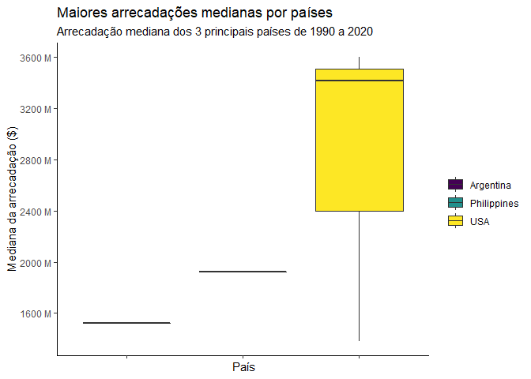

#### **Legenda**: Philippines: Filipinas; USA: Estados Unidos da América.

*Valores em milhões de dólares (M)*

**Gráfico 2**. Análise de evolução de arrecadação por atletas citados na Forbes (1990-2020)**

[figure not shown]

*Valores em milhões de dólares (M)*

Avaliando o **Gráfico 2** podemos notar uma evolução na arrecadação dos atletas, entretanto, destacamos a queda referente aos anos com a presença da pandemia de COVID-19, possivelmente impactando em eventos presenciais e compra de produtos, diminuindo assim a arrecadação médias dos atletas. Demostrando assim, que o esporte como fenômeno cultural, pode ser um excelente indicador de crises econômicas e sociais.

## Arrecadação por esporte

**Tabela 2**. Faturamento acumulado por esportes (1990-2020)

| Esporte | Arrecadação (M) |
| --- | --- |
| Basquete | 41199.6 |
| Lutas (boxe e MMA) | 28773.6 |
| Futebol | 26682.0 |
| Golf | 25638.0 |
| Automobilismo | 15150.0 |
| Tênis | 12207.6 |
| Futebol Americano | 11534.4 |
| Basebol | 1753.2 |
| Hockey no gelo | 908.4 |
| Ciclismo | 336.0 |

*Arrecadação em milhões de dólares por ano*

**Gráfico 3**. Evolução da arrecadação dos 3 esportes que mais lucraram, segundo a Forbes (1990-2020)

[figure not shown]

*Arrecadação em milhões de dólares por ano*

### **Análise individual por esporte**

#### **Basquete**

O basquete mesmo sendo um esporte coletivo gera imensa receita para seus All-Star, levando a modalidade ao topo do ranking da Forbes e dentro do nosso campeão em lucros podemos destacar as 5 maiores arrecadações individuais, segundo a **Tabela 3**.

**Tabela 3**. As 5 primeiras posições de atletas de basquete

| Atleta | Arrecadação (M) | Ano |
| --- | --- | --- |
| LeBron James | 1068.0 | 2019 |
| LeBron James | 1058.4 | 2020 |
| LeBron James | 1034.4 | 2017 |
| LeBron James | 1026.0 | 2018 |
| Stephen Curry | 957.6 | 2019 |

*Arrecadação em milhões de dólares por ano*

[figure not shown]

Foto s2.glbimg.com/

Nesta tabela observamos a superioridade de Lebron James ocupando as 4 primeiras posições do ranking destas 3 décadas. Entretanto, ambos os atletas devem estar felizes da vida com suas contas bancárias, e **Stephen Curry** ainda mais com o título da NBA e o MVP das finais do ano de 2022.

#### **Lutas (Boxe e MMA)**

As lutas foram alavancadas nesta lista pelas apostas astronômicas, e especificamente, o boxe se destacaram na 2ª posição na análise por esportes, como destaque podemos citar os 5 primeiros atletas em arrecadação, conforme **Tabela 4**.

**Tabela 4**. As 5 primeiras posições de atletas de lutas

| Atleta | Arrecadação (M) | Ano |
| --- | --- | --- |
| Floyd Mayweather | 3600 | 2015 |
| Floyd Mayweather | 3420 | 2018 |
| Manny Pacquiao | 1920 | 2015 |
| Floyd Mayweather | 1260 | 2014 |
| Conor McGregor | 1188 | 2018 |

*Arrecadação em milhões de dólares por ano*

Os maires arrecadadores são do boxe, tendo como maior arrecadador o lutador **Floyd Mayweather**, com arrecadação anual de assustadores $**3600M** em **2015**. Além disso, assumindo as 2 primeiras posições deste ranking, seguido pelo lutador **Manny Pacquiao**.

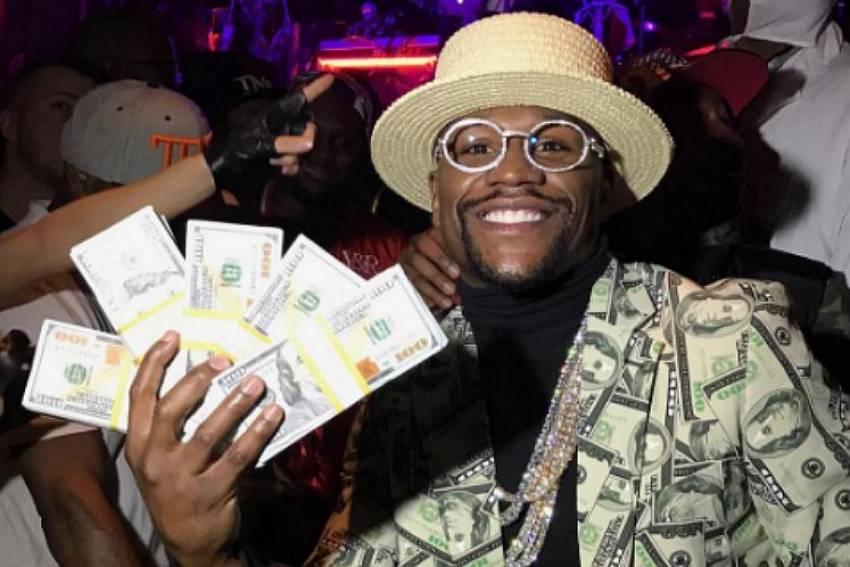

Foto da [Veja](https://veja.abril.com.br/wp-content/uploads/2017/03/floyd.jpg?quality=70&strip=info&resize=850,567)

Outro destaque é a aparição de outra modalidade de combate, o MMA, com um único representante o irlandes **Conor McGregor**, lucrando $**1188M** no ano de **2018**, ficando conhecido por promover suas lutas e desafiar os adversários para lucrar com as bolsas de apostas.

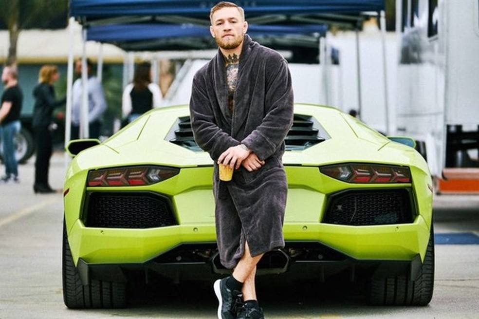

Foto do site s2.glbimg.com

#### **Futebol**

Fechando o nosso pódio na 3.ª posição encontramos o futebol, esporte com diversas competições ocorrendo simultaneamente no mundo, tem como destaque a arrecadação das equipes européias, com suas ligas bem estruturadas e os melhores atletas do globo. Além disso, a copa do mundo realizada a cada 4 anos movimenta valores gigantescos. Por fim, levando seus astros a faturar boladas de dinheiro, conforme o **Tabela 5**

**Tabela 5**. As 5 primeiras posições de atletas de futebol

| Atleta | Arrecadação (M) | Ano |
| --- | --- | --- |
| Lionel Messi | 1524 | 2019 |
| Lionel Messi | 1332 | 2018 |
| Cristiano Ronaldo | 1308 | 2019 |
| Cristiano Ronaldo | 1296 | 2018 |
| Neymar | 1260 | 2019 |
| Cristiano Ronaldo | 1260 | 2020 |

*Arrecadação em milhões de dolares por ano*

Quando avaliado individualmente Messi apresenta o maior valor para um só ano, entretanto, quando somamos as arrecadações durante os anos, Cristiano Ronaldo ultrapassa o Argentino no pódio. **Gráfico 4**. Arrecadação somada dos principais jogadores de futebol na lista Forbes

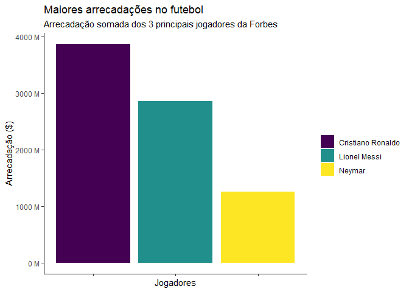

*Arrecadação em milhões de dolares por ano*

**Rivalidade até na lista Forbes**

A disputa vai além das quatro linhas e parece que o Neymar não fatura mais nem fora delas.

[figure not shown]

Foto do site [conteudo.imguol.com.br](https://conteudo.imguol.com.br/c/esporte/0a/2020/03/05/lionel-messi-cristiano-ronaldo-e-neymar-em-composicao-de-fotos-da-fifa-antes-da-copa-do-mundo-de-2018-1583453764233_v2_900x506.jpg.webp)

## **Grandes esportes fora do pódio**

### *Esportes americanos*

Impressionantemente, quando analisamos as maiores arrecadações por ano dos esportes americanos (i.e. **futebol americano**, **basebol** e **Hoquey**) encontramos nas 10 primeiras posições atletas da bola oval.

**Tabela 6**. Principais atletas na Forbes de Esportes Americanos

| Atleta | Arrecadação (M) | Ano |
| --- | --- | --- |
| Russell Wilson | 1074.0 | 2019 |
| Aaron Rodgers | 1071.6 | 2019 |
| Matt Ryan | 807.6 | 2018 |
| Kirk Cousins | 726.0 | 2020 |
| Matthew Stafford | 714.0 | 2018 |
| Carson Wentz | 709.2 | 2020 |
| Cam Newton | 637.2 | 2016 |
| Drew Brees | 612.0 | 2013 |
| Andrew Luck | 600.0 | 2017 |
| Aaron Rodgers | 588.0 | 2013 |

*Arrecadação em milhões de dólares por ano*

**Gráfico 5** . Arrecadação somada dos principais atletas de esportes americanos

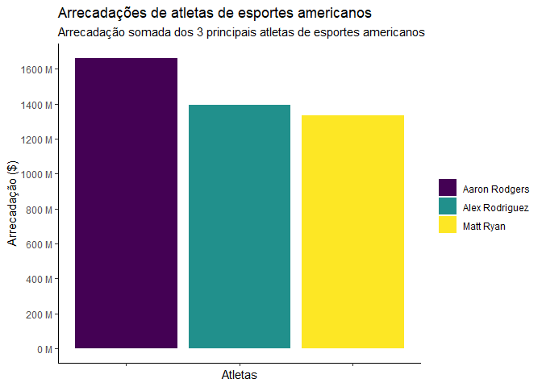

Quando somamos todas as aparições de atletas de esportes americanos na lista da Forbes encontramos a presença do atleta de basebol **Alex Rodriguez**, mas acompanhado por dois quarterbacks da NFL.

## **O Brasil na Forbes**

O Brasil quando se trata da lista da Forbes apenas engatinha, temos poucos atletas citados, entretanto, não surpreendente é a pequena lista, conforme **Tabela 7**.

**Tabela 7** Arrecadação brasileira na Forbes

| Atleta | Arrecadação (M) | Ano |
| --- | --- | --- |
| Neymar | 1260 | 2019 |
| Neymar | 1146 | 2020 |
| Neymar | 1080 | 2018 |
| Ronaldinho | 444 | 2008 |
| Ronaldinho | 372 | 2007 |
| Ayrton Senna | 264 | 1992 |
| Ayrton Senna | 156 | 1991 |
| Ayrton Senna | 120 | 1990 |

*Arrecadação em milhões de dolares por ano*

Nesta lista podemos destacar o saudoso piloto de Formula 1, **Ayrton Senna**.

[figure not shown]

Foto do site [i0.wp.com/gamehall.com.br](https://i0.wp.com/gamehall.com.br/wp-content/uploads/2021/09/horizon-chase-turbo-ayrton-senna.jpg?resize=780%2C470&ssl=p)

**Gráfico 6**. Soma de faturamento de atletas brasileiros na lista da forbes

[figure not shown]

*Arrecadação em milhões de dólares por ano*

Fechando este pódio podemos destacar os dois astros do futebol, mostrando que pelo menos para a Forbes somos o país do futebol.

[figure not shown]

## **O futuro da Lista Forbes**

A cultura educacional e desportiva americana proporciona a seus atletas inclusão em grande e lucrativas ligas, trazendo grandes retornos financeiros, mas é claro que os shows e eventos que produzem em torno das suas competições favorecem esses lucros e esta brutal diferença com relação aos outros países citados nesta lista, por este motivo dificilmente veremos uma mudança neste pódio na próxima década. Entretanto, o Brasil deve analisar este retorno econômico e social da cultura educacional e desportiva americana que inclui os seus alunos/atletas nas diversas ligas nacionais e mundiais, mas principalmente que une esporte e educação.

**A mudança social passa pela educação, mas também pelo esporte.**